# Workshop Week 8

Author

Affiliation

STAT5003

School of Mathematics and Statistics

# 1 Learning Outcomes

**Learning Outcomes**

- Investigate the impact of missing data on modelling
  1. Use `ampute` from the `mice` package to simulate missingness
  2. Observe the impact of missing data on regression models
  3. Determine how missing data can lead to different conclusions
  4. Explore random imputation with `rnorm`

# 2 Loading Packages

At the start of your R workshop, load all necessary packages to ensure a smooth session. Here’s an example:

```r
library(tidyverse)  # Data science packages
library(ggplot2)    # Data visualization
library(ggthemes)   # Inclusive ggplot themes
library(here)       # File paths
library(mice)
library(visdat)
library(themis)
library(rsample)    # Training/test sets split
library(caret)
```

# 3 Simple Regression

In this workshop, we’ll be using the `skin-cancer.csv` data on Canvas. This dataset contains information on mortality rates (number of deaths per 10 million people) against the latitude of the state for some US states. We’ll explore how missing data will impact our conclusions from this dataset.

Let’s consider the conclusions we can draw from this dataset with a simple regression of skin cancer mortality against latitude.

```r
full.data <- read.csv(here("datasets", "skin-cancer.csv"), header = TRUE)
```

Conduct a simple linear regression with the Mortality rates as the response and Latitude as the predictor. Plot the data along with the regression and interpret the regression output.

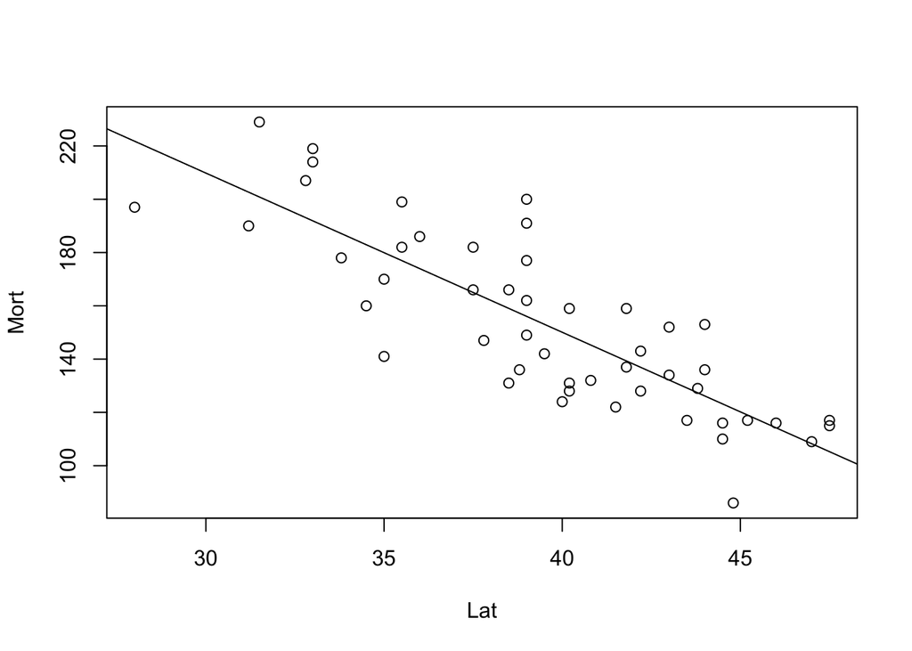

```r
full.lm <- lm(Mort ~ Lat, data = full.data)
plot(Mort ~ Lat, data = full.data)
abline(full.lm)
```

```r
summary(full.lm)
```

```
Call:
lm(formula = Mort ~ Lat, data = full.data)

Residuals:
    Min      1Q  Median      3Q     Max
-38.972 -13.185   0.972  12.006  43.938

Coefficients:
            Estimate Std. Error t value Pr(>|t|)
(Intercept) 389.1894    23.8123   16.34  < 2e-16 ***
Lat          -5.9776     0.5984   -9.99 3.31e-13 ***
---
Signif. codes:  0 '***' 0.001 '**' 0.01 '*' 0.05 '.' 0.1 ' ' 1

Residual standard error: 19.12 on 47 degrees of freedom
Multiple R-squared:  0.6798,    Adjusted R-squared:  0.673
F-statistic:  99.8 on 1 and 47 DF,  p-value: 3.309e-13
```

```r
## alternatively, we can use `broom` package to get tidy version of the model results--recap in Week 3's workshop
library(broom)
tidy(full.lm)
```

```
# A tibble: 2 × 5
  term        estimate std.error statistic  p.value
  <chr>          <dbl>     <dbl>     <dbl>    <dbl>
1 (Intercept)   389.      23.8       16.3  5.12e-21
2 Lat            -5.98     0.598     -9.99 3.31e-13
```

## 3.1 Effect of missingness on simple regression

Now, let’s examine the impact of introducing missing values in the predictor in regression modelling.

**Simulate missing values in Latitude**

Simulate missingness in the Latitude feature such that approximately half of its values are missing at random (MAR)—that is, missing values are introduced randomly but with a dependency on another variable, in this case, Mortality. This means the probability of a Latitude value being missing depends on the value of Mortality, rather than being completely independent (i.e., not MCAR).

A convenient way to introduce missingness is by using the `mice::ampute()` function. This function returns a list, and the data containing the missing values can be accessed via the `amp` element.

For example, if you store the result in an object called `available.data`, the amputed dataset can accessed via `available.data$amp`. Assign this object as `amputed_data` and use `vis_miss` and `vis_dat` to visualise the missing pattern.

```r
set.seed(5003)
available.data = ampute(full.data,
                        prop = 0.5,
                        patterns = data.frame(Mort = 1, Lat = 0))


head(available.data$amp)
```

```
  Mort  Lat
1  219   NA
2  160   NA
3  170 35.0
4  182   NA
5  149   NA
6  159 41.8
```

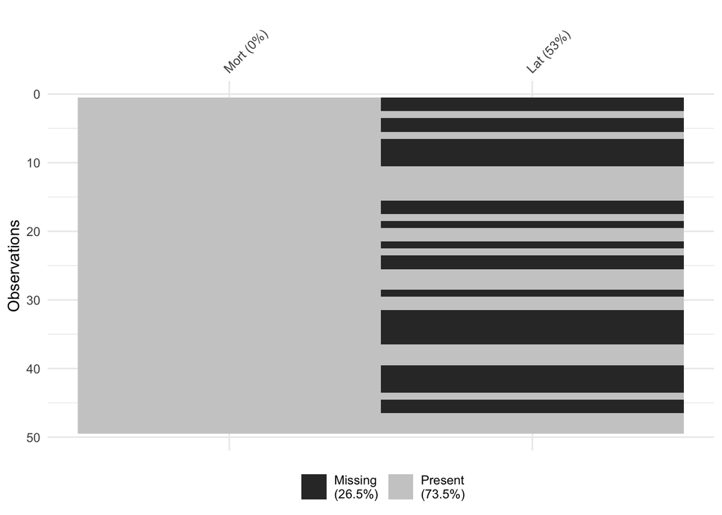

```r
amputed_data <- available.data$amp



vis_miss(amputed_data)
```

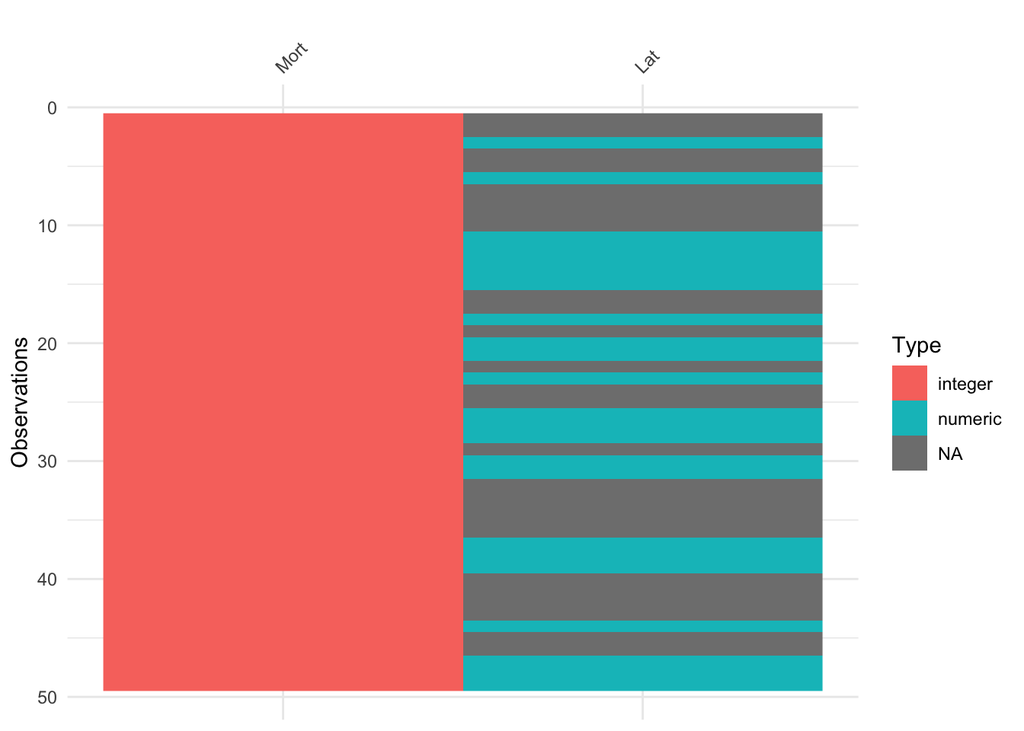

```r
vis_dat(amputed_data)
```

**Effect of missingness in the predictor**

Now, refit the simple linear regression using the `amputed_data` with Mortality as the response and Latitude as the predictor. Show that it is not consistent with the original regression using the full data.

Note that `R` will automatically remove missing values from the model when using `lm`. In other words, it takes a complete-case approach.

```r
available.lm <- lm(Mort ~ Lat, data = amputed_data)


plot(Mort ~ Lat, data = full.data, col = "black")

points(Mort ~ Lat, data = amputed_data, pch = 18, col = "blue")

abline(full.lm, lty = 'dotted', col = "black")

abline(available.lm, col = "blue")

summary(available.lm)
```

```
Call:
lm(formula = Mort ~ Lat, data = amputed_data)

Residuals:
    Min      1Q  Median      3Q     Max
-30.923 -12.402  -1.923   9.934  39.530

Coefficients:
            Estimate Std. Error t value Pr(>|t|)
(Intercept)  350.893     43.794   8.012 8.03e-08 ***
Lat           -5.113      1.073  -4.764 0.000105 ***
---
Signif. codes:  0 '***' 0.001 '**' 0.01 '*' 0.05 '.' 0.1 ' ' 1

Residual standard error: 18.05 on 21 degrees of freedom
  (26 observations deleted due to missingness)
Multiple R-squared:  0.5194,    Adjusted R-squared:  0.4965
F-statistic: 22.69 on 1 and 21 DF,  p-value: 0.0001049
```

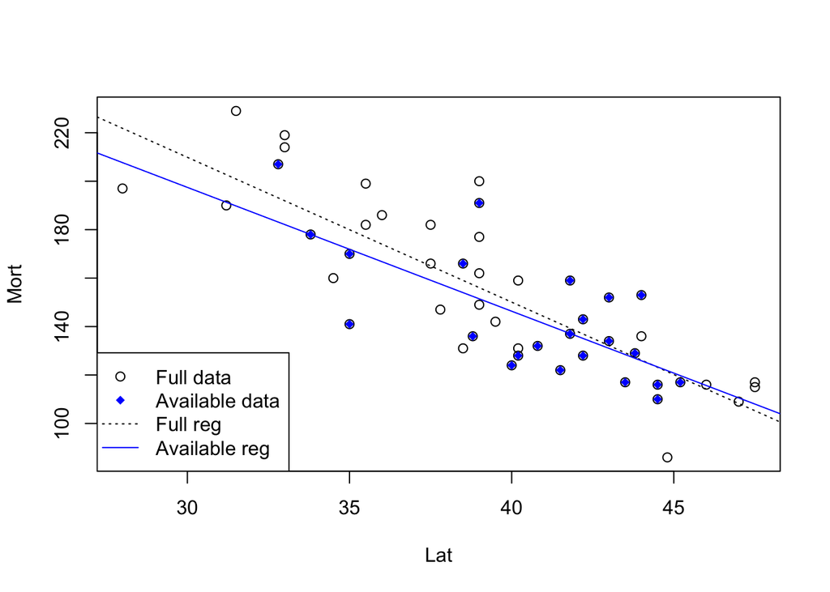

```r
legend("bottomleft", legend = c("Full data", "Available data", "Full reg", "Available reg"), col = rep(c("black", "blue"), 2), pch = c(21, 18, rep(NA, 2)), lty = c(rep(NA, 2), c("dotted", "solid")))
```

```r
tidy(full.lm)
```

```
# A tibble: 2 × 5
  term        estimate std.error statistic  p.value
  <chr>          <dbl>     <dbl>     <dbl>    <dbl>
1 (Intercept)   389.      23.8       16.3  5.12e-21
2 Lat            -5.98     0.598     -9.99 3.31e-13
```

```r
tidy(available.lm)
```

```
# A tibble: 2 × 5
  term        estimate std.error statistic      p.value
  <chr>          <dbl>     <dbl>     <dbl>        <dbl>
1 (Intercept)   351.       43.8       8.01 0.0000000803
2 Lat            -5.11      1.07     -4.76 0.000105
```

The differences are slight but can see that the intercept and slope estimates are off with a smaller intercept on the model computed with missing data and the slope is also less steep at -5.11 instead of -5.98.

## 3.2 Random Imputation Using Linear Regression + Noise

We will now perform random imputation to estimate the missing Latitude values in the `amputed_data`. This involves two key steps.

**Fit a NEW simple linear regression model with Latitude as the response**

Conduct a simple linear regression where Latitude is the response and Mortality `(Latitude ~ Mortality)` is the predictor but using the `amputed_data`.

**Note again: `R` will automatically remove missing values when using `lm`. In other words, it takes a complete-case approach.**

```r
simple.missing <- lm(Lat ~ Mort, data = amputed_data)

## summary(simple.missing)

tidy(simple.missing)
```

```
# A tibble: 2 × 5
  term        estimate std.error statistic  p.value
  <chr>          <dbl>     <dbl>     <dbl>    <dbl>
1 (Intercept)   55.2      3.10       17.8  3.70e-14
2 Mort          -0.102    0.0213     -4.76 1.05e- 4
```

**Predict and Add Random Noise**

Next, for rows where Latitude is missing, use the fitted model to generate predicted values.

To reflect natural variability, add random noise drawn from a normal distribution (`rnorm`) with mean zero and standard deviation equal to the residual standard error from the fitted model. Plot both regression lines on the same graph

```r
## extract the mortality values whose lattitudes are missing
missing.lats <- amputed_data |>
  filter(is.na(Lat)) |>
  dplyr::select(Mort)

# Impute with our simple linear model with missing data
simple.preds <- predict(simple.missing, newdata = missing.lats)

# Extract the residual standard error from the fitted model
# Base R
sigma(simple.missing)
```

```
[1] 2.54336
```

```r
# Broom package
# glance(simple.missing)[3]

# Add random noise
rand.preds <- simple.preds + rnorm(length(simple.preds), sd = sigma(simple.missing))

imputed.data <- amputed_data
imputed.data$Lat[is.na(imputed.data$Lat)] <- rand.preds

imputed.lm <- lm(Mort ~ Lat, data = imputed.data)
```

**Compare Regression Lines (Full versus Imputed Data)**

Now, fit a regression model on the imputed dataset and compare it with the model from the original full data. Plot both regression lines on the same graph.

```r
tidy(imputed.lm)
```

```
# A tibble: 2 × 5
  term        estimate std.error statistic  p.value
  <chr>          <dbl>     <dbl>     <dbl>    <dbl>
1 (Intercept)   379.      23.4       16.2  7.47e-21
2 Lat            -5.71     0.587     -9.73 7.66e-13
```

```r
tidy(full.lm)
```

```
# A tibble: 2 × 5
  term        estimate std.error statistic  p.value
  <chr>          <dbl>     <dbl>     <dbl>    <dbl>
1 (Intercept)   389.      23.8       16.3  5.12e-21
2 Lat            -5.98     0.598     -9.99 3.31e-13
```

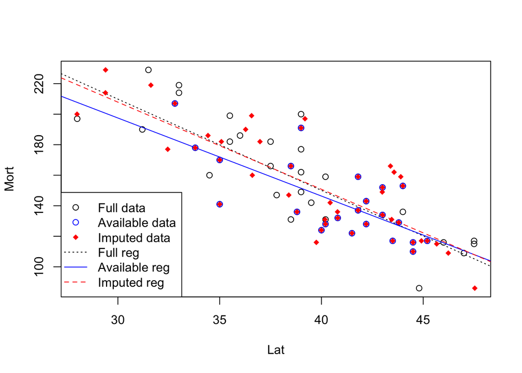

```r
full.range <- lapply(full.data, range)
imputed.range <- lapply(imputed.data, range)
yrange <- range(c(full.range$Mort, imputed.range$Mort))
xrange <- range(c(full.range$Lat, imputed.range$Lat))
plot(Mort ~ Lat, data = full.data, ylim = yrange, xlim = xrange)
abline(full.lm, lty = "dotted")
points(Mort ~ Lat, data = amputed_data, col = "blue", pch = 21)
abline(available.lm, col = "blue")
points(Mort ~ Lat, data = imputed.data, col = "red", pch = 18)
abline(imputed.lm, lty = "dashed", col = "red")
legend("bottomleft", legend = c("Full data", "Available data", "Imputed data", "Full reg", "Available reg", "Imputed reg"),
       col = rep(c("black", "blue", "red"), 2),
       pch = c(21, 21, 18, rep(NA, 3)),
       lty = c(rep(NA, 3), c("dotted", "solid", "dashed")))
```

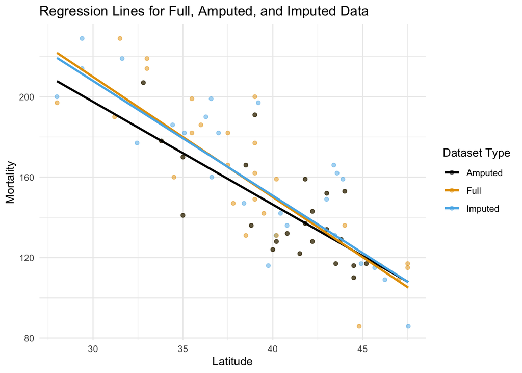

```r
## GGPLOT Solution

# Add a source column
imputed.data$Source <- "Imputed"
full.data$Source <- "Full"
amputed_data$Source <- "Amputed"

# Combine all datasets
plot_data <- rbind(imputed.data, full.data, amputed_data)

# Plot


ggplot(plot_data, aes(x = Lat, y = Mort, color = Source)) +
  geom_point(alpha = 0.5) +
  stat_smooth(method = "lm", se = FALSE, fullrange = TRUE) +
  labs(
    title = "Regression Lines for Full, Amputed, and Imputed Data",
    x = "Latitude",
    y = "Mortality",
    color = "Dataset Type"
  ) +
  theme_minimal() +
  scale_color_colorblind()
```

For this dataset, even with random imputation, our results are much closer to the complete regression as opposed to no imputation. This will not necessarily always be the case, but in this particular example, we can see that it is true.

# 4 Handling Class Imbalance with SMOTE

In this exercise, we will explore how to handle class imbalance in a credit card fraud detection problem using the SMOTE technique from the `themis` package. We’ll build a SVM classifier on the balanced data and evaluate its performance.

Download the `creditcard_sub.csv` dataset from Canvas which contains a highly imbalanced binary classification problem (more non-fradulent cases than fadulent cases), and read into R. Ensure that the `Class` variable is coded as a factor.

```r
card <- read.csv(here("datasets", "creditcard_sub.csv"), header = TRUE)

table(card$Class)
```

```
  0   1
450  50
```

```r
head(card)
```

```
  Class Amount
1     1   1.00
2     0 100.25
3     1   1.52
4     0  50.00
5     0   3.39
6     0  15.99
```

```r
str(card)
```

```
'data.frame':   500 obs. of  2 variables:
 $ Class : int  1 0 1 0 0 0 0 0 0 0 ...
 $ Amount: num  1 100.25 1.52 50 3.39 ...
```

```r
card <- card |> mutate(Class = as.factor(Class))
```

**Split into Training and Test Sets**

This week, we will explore `rsample` package to randomly split the subset into a 75% training and 25% test set using `initial_split()`. Make sure to stratify on the `Class` variable to maintain the imbalance in both sets. *As an exercise, split the data using `caret::CreateDataParticipation`*.

**Recall from lecture that data needs to be divided into training/test sets before doing any SMOTE. Otherwise, you will leak information from training to test data set.**

```r
set.seed(5003)

data_split <- initial_split(card, prop = 0.75, strata = Class)
train_data <- training(data_split)
test_data <- testing(data_split)

## using caret package, and using this will create a slightly different data split.
##set.seed(5003)

##index <- createDataPartition(card$Class, p = 0.75)[[1]]
##train_data <- card[index, ]
##test_data <- card[-index,]
```

**Balance the Training Set using SMOTE**

Use the `step_smote()` function from the `themis` package to synthetically balance the minority class within the training data set. Assign the result as `balanced_data`.

**This helps ensure that the class imbalance is addressed only during the model training, without leaking information from the test**.

```r
balanced_data <- recipe(Class ~ Amount, data = train_data) |> ## the recipe is the model formula, here we use Amount to predict the credit card status
  step_smote(Class) |>
  prep() |>
  juice()

## After SMOTE, both classes have the same number of cases
table(balanced_data$Class)
```

```
  0   1
337 337
```

```r
table(train_data$Class)
```

```
  0   1
337  37
```

**Train an SVM Model, Predict and Evaluate Performance**

Now build a `SVM` classifier with an RBF kernel and train it using the balanced data. There are three hyperparameters associated with `SVM`: `sigma`, `C` and `Weight`.

1. Use `caret::train()`to find the best combination of hyperparameters (sigma, C, and Weight) by performing five repeated cross-validation on the balanced_data.
2. Identify the Best Hyperparameters and refit on the Balanced Training Set.
3. Predict on the test_data, and use `confusionMatrix` to report the performance metrics.

```r
svm.radial.model <- caret::train(Class ~ Amount, data = balanced_data,
                          method = "svmRadialWeights",
                          trControl = trainControl(method = "repeatedcv", repeats = 5))

## Look at the results, and select the best combo of the hyperparameter

which.max(svm.radial.model$results[,4]) ## it returns 7 referring to row 7 combo
```

```
[1] 7
```

```r
# Define the grid with only one combination
tune_grid <- expand.grid(
  sigma = svm.radial.model$results[7,1],
  C = svm.radial.model$results[7,2],
  Weight = svm.radial.model$results[7,3]
)

## Use the best combo and refit on the whole data set to train the model and make predictions on the test set
svm.radial.model.final <- caret::train(Class ~ Amount, data = balanced_data,
                          method = "svmRadialWeights", tuneGrid = tune_grid)


svm.predictions <- predict(svm.radial.model.final, test_data)

confusionMatrix(test_data$Class, svm.predictions, positive = "1")
```

```
Confusion Matrix and Statistics

          Reference
Prediction  0  1
         0 83 30
         1  6  7

               Accuracy : 0.7143
                 95% CI : (0.627, 0.7912)
    No Information Rate : 0.7063
    P-Value [Acc > NIR] : 0.4663941

                  Kappa : 0.1502

 Mcnemar's Test P-Value : 0.0001264

            Sensitivity : 0.18919
            Specificity : 0.93258
         Pos Pred Value : 0.53846
         Neg Pred Value : 0.73451
             Prevalence : 0.29365
         Detection Rate : 0.05556
   Detection Prevalence : 0.10317
      Balanced Accuracy : 0.56089

       'Positive' Class : 1
```